```
Title: Reproducible research project 1 - activity pattern
Output: html document
```

## Load the data

```r
act <- read.csv("activity.csv")
```

### Total number of steps taken per day

```r
sumSteps <- tapply(act$steps, act$date, sum)
```

### Histogram of the total number of steps taken each day

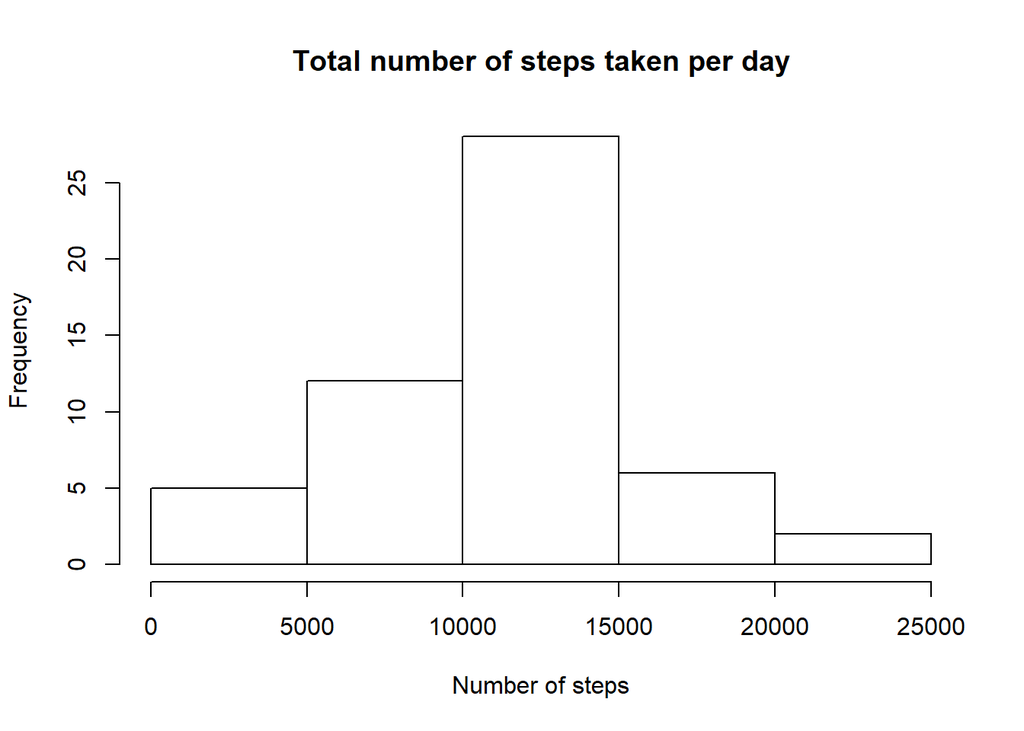

```r
hist(sumSteps, xlab = "Number of steps", main = "Total number of steps taken per day")
```

```r
meanSteps <- mean(sumSteps, na.rm = TRUE)
medianSteps <- median(sumSteps, na.rm = TRUE)
```

## Q.2. What is the average dailiy acitivity pattern?

### Make a time series plot of the 5-minute interval (x-axis) and the average number of steps taken, averaged across all days(y-axis)

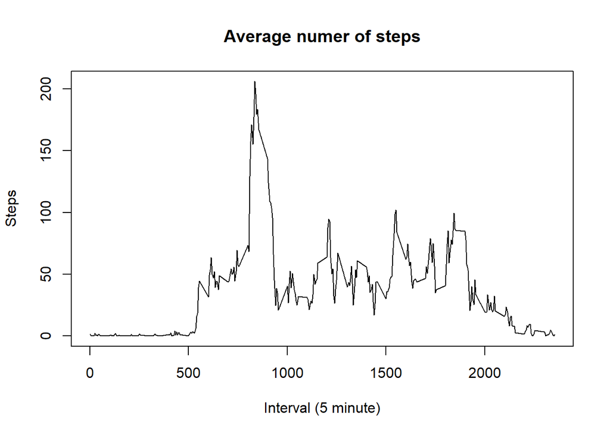

```r
stepsInt <- tapply(act$steps, act$interval,mean, na.rm = TRUE)
plot(as.numeric(names(stepsInt)),
     stepsInt,
     xlab = "Interval (5 minute)",
     ylab = "Steps",
     main = "Average numer of steps",
     type = "l")
```

### Which 5-min interval, on average across all the days in the dataset, contains the maximum number of steps?

```r
which.max(stepsInt)
```

```
## 835
## 104
```

Explanation: Interval 835 has the max activity at 206.1698 steps.

## Q.3. Imputing missing values

### Calculate & report the total no. of missing values in the dataset (i.e. the total no. of rows with NAs).

```r
sum(is.na(act$steps))
```

```
## [1] 2304
```

**Explanation: there are 2304 missing values in this datasets.**

### Devise a strategy for filling in all of the missing values in the dataset.

**I will use mean number of steps across all days.**

### Create a new dataset that is equal to the original dataset but with the missing data filled in.

```r
stepsInt <- tapply(act$steps, act$interval, mean, na.rm = TRUE)
act.split <- split(act, act$interval)
for(i in 1:length(act.split)){
  act.split[[i]]$steps[is.na(act.split[[i]]$steps)] <- stepsInt[i]
}
act.imputed <- do.call("rbind", act.split)
act.imputed <- act.imputed[order(act.imputed$date),]
```

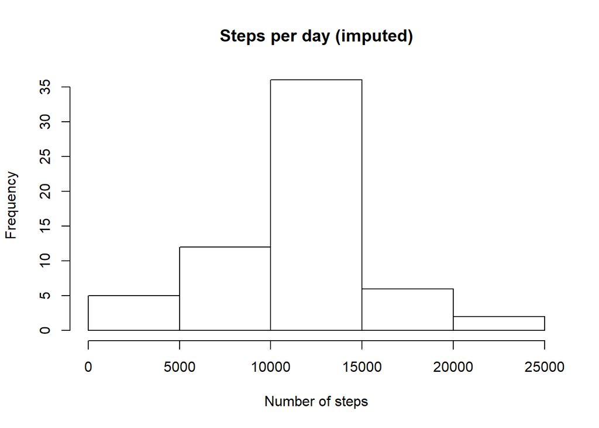

```r
sumSteps.imputed <- tapply(act.imputed$steps, act.imputed$date, sum)
hist(sumSteps.imputed, xlab = "Number of steps", main = "Steps per day (imputed)")
```

```r
meansumSteps.imputed <- mean(sumSteps.imputed, na.rm = TRUE)
mediansumSteps.imputed <- median(sumSteps.imputed, na.rm = TRUE)
meansumSteps.imputed
```

```
## [1] 10766.19
```

```r
mediansumSteps.imputed
```

```
## [1] 10766.19
```

## Q.4. Are there differences in activity patterns between weekdays and weekends?

### Create a new factor variable in the dataset with two levels - “weekday” and “weekend” indicating whether a given date is a weekday or weekend day.

```r
act.imputed$day <- ifelse(weekdays(as.Date(act.imputed$date)) == "Saturday" | weekdays(as.Date(act.imputed$date)) == "Sunday", "weekend", "weekday")
```

### Calculate average steps per interval for weekdays.

```r
stepsInt.weekday <- tapply(act.imputed[act.imputed$day == "weekday" ,]$steps, act.imputed[act.imputed$day == "weekday" ,]$interval, mean, na.rm = TRUE)
```

### Calculate average steps per interval for weekends.

```r
stepsInt.weekend <- tapply(act.imputed[act.imputed$day == "weekend" ,]$steps, act.imputed[act.imputed$day == "weekend" ,]$interval, mean, na.rm = TRUE)
```

### Make panel plot of 5 min interval (x-axis) and the average number of steps taken (y-axis).

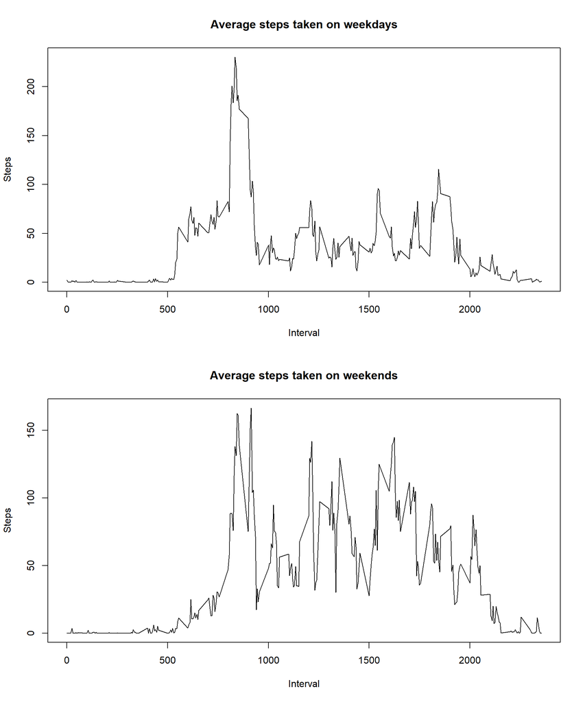

```r
par(mfrow = c(2, 1))
plot(as.numeric(names(stepsInt.weekday)),
     stepsInt.weekday,
     xlab = "Interval",
     ylab = "Steps",
     main = "Average steps taken on weekdays",
     type = "l")

plot(as.numeric(names(stepsInt.weekend)),
     stepsInt.weekend,
     xlab = "Interval",
     ylab = "Steps",
     main = "Average steps taken on weekends",
     type = "l")
```